# EfficientNet Keras - Regression

Here in this kernel, we are going to train Efficient Net architecture (pretrained on imagenet) using past competition data (not cropped) as the training set and new competition data as the validation set.

Due to kaggle kernels computing limitations, we are going to load the train set sequentially as I described here: [[APTOS19] DenseNet Trained with Old and New Data](https://www.kaggle.com/raimonds1993/aptos19-densenet-trained-with-old-and-new-data).

[Inference Kernel](https://www.kaggle.com/raimonds1993/aptos19-inference-efficientnet-keras-regression). With this approach, I achieved 0.75 Public LB.

**EDIT:** The score can be improved up to ~ 0.78 just by fine tuning the model on new competition data. So, one could use this as a starting point to build a stronger model. :)

If you enjoyed the kernel, **please upvote**. I would really appreciate that!

### Credits

- [APTOS 2019: DenseNet Keras Starter](https://www.kaggle.com/xhlulu/aptos-2019-densenet-keras-starter), by **Xhlulu**
- [Previous competition's data](https://www.kaggle.com/tanlikesmath/diabetic-retinopathy-resized), uploaded by **ilovescience**
- [Kappa Optimizer](https://www.kaggle.com/abhishek/optimizer-for-quadratic-weighted-kappa), by **Abhishek**

```python
# To have reproducible results and compare them
nr_seed = 2019
import numpy as np
np.random.seed(nr_seed)
import tensorflow as tf
tf.set_random_seed(nr_seed)
```

# EfficientNet

[figure not shown]

### [Here is the paper](https://arxiv.org/abs/1905.11946)

> The core idea about Efficient Nets is the use of compound scaling - using a weighted scale of three inter-connected hyper parameters of the model - Resolution of the input, Depth of the Network and Width of the Network.

We are going to use keras-efficientnets library.

Also efficientnet library would work fine.

```python
!pip install keras_efficientnets
```

```python
# Libraries
import json
import math
import os


import scipy as sp
from functools import partial
from collections import Counter
import json

import cv2
from PIL import Image
import numpy as np
from keras import backend as K
from keras import layers
from keras_efficientnets import *
from keras.callbacks import Callback, ModelCheckpoint
from keras.preprocessing.image import ImageDataGenerator
from keras.models import Sequential
from keras.optimizers import Adam
import matplotlib.pyplot as plt
import pandas as pd
from sklearn.model_selection import train_test_split
from sklearn.metrics import cohen_kappa_score, accuracy_score
from tqdm import tqdm, tqdm_notebook
import gc
import warnings
warnings.filterwarnings("ignore")

%matplotlib inline
```

```python
# Image size
im_size = 224
# Batch size
BATCH_SIZE = 32
```

# Loading & Merging

```python
new_train = pd.read_csv('../input/aptos2019-blindness-detection/train.csv')
old_train = pd.read_csv('../input/diabetic-retinopathy-resized/trainLabels.csv')
print(new_train.shape)
print(old_train.shape)
```

```
(3662, 2)
(35126, 2)
```

```python
old_train = old_train[['image','level']]
old_train.columns = new_train.columns
old_train.diagnosis.value_counts()

new_train['id_code'] = '../input/aptos2019-blindness-detection/train_images/' + new_train['id_code'].astype(str) + '.png'
old_train['id_code'] = '../input/diabetic-retinopathy-resized/resized_train/resized_train/' + old_train['id_code'].astype(str) + '.jpeg'

train_df = old_train.copy()
val_df = new_train.copy()
```

```python
# Let's shuffle the datasets
train_df = train_df.sample(frac=1).reset_index(drop=True)
val_df = val_df.sample(frac=1).reset_index(drop=True)
print(train_df.shape)
print(val_df.shape)
```

```
(35126, 2)
(3662, 2)
```

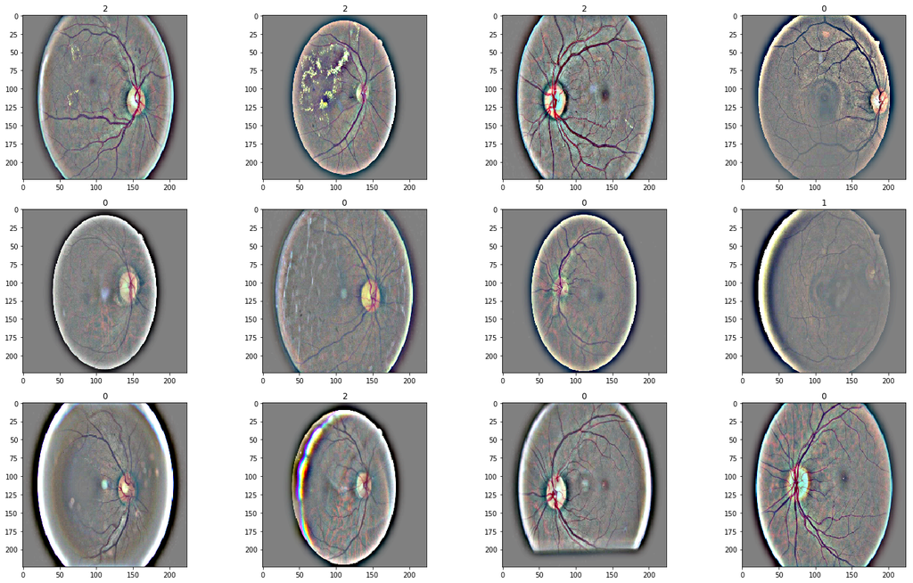

```python
def display_samples(df, columns=4, rows=3):
    fig=plt.figure(figsize=(5*columns, 4*rows))

    for i in range(columns*rows):
        image_path = df.loc[i,'id_code']
        image_id = df.loc[i,'diagnosis']
        img = cv2.imread(f'{image_path}')
        img = cv2.cvtColor(img, cv2.COLOR_BGR2RGB)
        img = cv2.resize(img, (im_size,im_size))
        img = cv2.addWeighted(img,4,cv2.GaussianBlur(img, (0,0), im_size/40) ,-4 ,128)

        fig.add_subplot(rows, columns, i+1)
        plt.title(image_id)
        plt.imshow(img)

    plt.tight_layout()

# display train images
display_samples(train_df)
```

# Process Images

After this [thread](https://www.kaggle.com/c/aptos2019-blindness-detection/discussion/100815#latest-582932), I changed the training set (old comp data) preprocessing.

```python
def crop_image1(img,tol=7):
    # img is image data
    # tol  is tolerance

    mask = img>tol
    return img[np.ix_(mask.any(1),mask.any(0))]

def crop_image_from_gray(img,tol=7):
    if img.ndim ==2:
        mask = img>tol
        return img[np.ix_(mask.any(1),mask.any(0))]
    elif img.ndim==3:
        gray_img = cv2.cvtColor(img, cv2.COLOR_RGB2GRAY)
        mask = gray_img>tol

        check_shape = img[:,:,0][np.ix_(mask.any(1),mask.any(0))].shape[0]
        if (check_shape == 0): # image is too dark so that we crop out everything,
            return img # return original image
        else:
            img1=img[:,:,0][np.ix_(mask.any(1),mask.any(0))]
            img2=img[:,:,1][np.ix_(mask.any(1),mask.any(0))]
            img3=img[:,:,2][np.ix_(mask.any(1),mask.any(0))]
            img = np.stack([img1,img2,img3],axis=-1)
        return img

def preprocess_image(image_path, desired_size=224):
    img = cv2.imread(image_path)
    img = cv2.cvtColor(img, cv2.COLOR_BGR2RGB)
    img = crop_image_from_gray(img)
    img = cv2.resize(img, (desired_size,desired_size))
    img = cv2.addWeighted(img,4,cv2.GaussianBlur(img, (0,0), desired_size/30) ,-4 ,128)

    return img

def preprocess_image_old(image_path, desired_size=224):
    img = cv2.imread(image_path)
    img = cv2.cvtColor(img, cv2.COLOR_BGR2RGB)
    img = cv2.resize(img, (desired_size,desired_size))
    img = cv2.addWeighted(img,4,cv2.GaussianBlur(img, (0,0), desired_size/40) ,-4 ,128)

    return img
```

```python
N = val_df.shape[0]
x_val = np.empty((N, im_size, im_size, 3), dtype=np.uint8)

for i, image_id in enumerate(tqdm_notebook(val_df['id_code'])):
    x_val[i, :, :, :] = preprocess_image(
        f'{image_id}',
        desired_size = im_size
    )
```

```python
y_train = train_df['diagnosis'].values
y_val = val_df['diagnosis'].values

print(y_train.shape)
print(x_val.shape)
print(y_val.shape)
```

```
(35126,)
(3662, 224, 224, 3)
(3662,)
```

```python
del new_train
del old_train
del val_df
gc.collect()
```

```
27061
```

# Creating keras callback for QWK

```python
class Metrics(Callback):

    def on_epoch_end(self, epoch, logs={}):
        X_val, y_val = self.validation_data[:2]

        y_pred = self.model.predict(X_val)

        coef = [0.5, 1.5, 2.5, 3.5]

        for i, pred in enumerate(y_pred):
            if pred < coef[0]:
                y_pred[i] = 0
            elif pred >= coef[0] and pred < coef[1]:
                y_pred[i] = 1
            elif pred >= coef[1] and pred < coef[2]:
                y_pred[i] = 2
            elif pred >= coef[2] and pred < coef[3]:
                y_pred[i] = 3
            else:
                y_pred[i] = 4

        _val_kappa = cohen_kappa_score(
            y_val,
            y_pred,
            weights='quadratic'
        )

        self.val_kappas.append(_val_kappa)

        print(f"val_kappa: {_val_kappa:.4f}")

        if _val_kappa == max(self.val_kappas):
            print("Validation Kappa has improved. Saving model.")
            self.model.save('model.h5')

        return
```

# Data Generator

```python
def create_datagen():
    return ImageDataGenerator(
        horizontal_flip = True,
        vertical_flip = True,
        rotation_range = 160,
        zoom_range=0.35
    )
```

# Model: EfficientNetB5

```python
effnet = EfficientNetB5(
    input_shape=(im_size,im_size,3),
    weights='imagenet',
    include_top=False
)
```

```
Downloading data from https://github.com/titu1994/keras-efficientnets/releases/download/v0.1/efficientnet-b5_notop.h5
```

```python
def build_model():
    model = Sequential()
    model.add(effnet)
    model.add(layers.Dropout(0.25))
    model.add(layers.Dense(2048))
    model.add(layers.LeakyReLU())
    model.add(layers.GlobalAveragePooling2D())
    model.add(layers.Dropout(0.5))
    model.add(layers.Dense(1, activation='linear'))

    model.compile(
        loss='mean_squared_error',
        optimizer=Adam(lr=0.0001,decay=1e-5),
        metrics=['mae']
    )

    return model
```

```python
model = build_model()
model.summary()
```

```
_________________________________________________________________
Layer (type)                 Output Shape              Param #
=================================================================
model_1 (Model)              (None, 7, 7, 2048)        28513520
_________________________________________________________________
dropout_1 (Dropout)          (None, 7, 7, 2048)        0
_________________________________________________________________
dense_1 (Dense)              (None, 7, 7, 2048)        4196352
_________________________________________________________________
leaky_re_lu_1 (LeakyReLU)    (None, 7, 7, 2048)        0
_________________________________________________________________
global_average_pooling2d_1 ( (None, 2048)              0
_________________________________________________________________
dropout_2 (Dropout)          (None, 2048)              0
_________________________________________________________________
dense_2 (Dense)              (None, 1)                 2049
=================================================================
Total params: 32,711,921
Trainable params: 32,539,185
Non-trainable params: 172,736
_________________________________________________________________
```

# Training & Evaluation

```python
num_bucket = 8
div = round(train_df.shape[0]/num_bucket)
div
```

```
4391
```

```python
results = pd.DataFrame({
                        'val_loss': [0.0],
                        'val_mean_absolute_error': [0.0],
                        'loss': [0.0],
                        'mean_absolute_error': [0.0],
                        'bucket': [0.0]
                        })
```

```python
# Epochs
epochs = [10,10,10,15,15,20,20,25]
kappa_metrics = Metrics()
kappa_metrics.val_kappas = []
```

```python
for i in range(0,num_bucket):
    if i != (num_bucket-1):
        print("Bucket Nr: {}".format(i))

        N = train_df.iloc[i*div:(1+i)*div].shape[0]
        x_train = np.empty((N, im_size, im_size, 3), dtype=np.uint8)
        for j, image_id in enumerate(tqdm_notebook(train_df.iloc[i*div:(1+i)*div,0])):
            x_train[j, :, :, :] = preprocess_image_old(f'{image_id}', desired_size = im_size)

        data_generator = create_datagen().flow(x_train, y_train[i*div:(1+i)*div], batch_size=BATCH_SIZE)
        history = model.fit_generator(
                        data_generator,
                        steps_per_epoch=x_train.shape[0] / BATCH_SIZE,
                        epochs=epochs[i],
                        validation_data=(x_val, y_val),
                        callbacks=[kappa_metrics]
                        )

        dic = history.history
        df_model = pd.DataFrame(dic)
        df_model['bucket'] = i
    else:
        print("Bucket Nr: {}".format(i))

        N = train_df.iloc[i*div:].shape[0]
        x_train = np.empty((N, im_size, im_size, 3), dtype=np.uint8)
        for j, image_id in enumerate(tqdm_notebook(train_df.iloc[i*div:,0])):
            x_train[j, :, :, :] = preprocess_image_old(f'{image_id}', desired_size = im_size)
        data_generator = create_datagen().flow(x_train, y_train[i*div:], batch_size=BATCH_SIZE)

        history = model.fit_generator(
                        data_generator,
                        steps_per_epoch=x_train.shape[0] / BATCH_SIZE,
                        epochs=epochs[i],
                        validation_data=(x_val, y_val),
                        callbacks=[kappa_metrics]
                        )

        dic = history.history
        df_model = pd.DataFrame(dic)
        df_model['bucket'] = i

    results = results.append(df_model)

    del data_generator
    del x_train
    gc.collect()

    print('-'*40)
```

```
Bucket Nr: 0
```

```
val_kappa: 0.5709
Validation Kappa has improved. Saving model.
val_kappa: 0.7601
Validation Kappa has improved. Saving model.
val_kappa: 0.7238
val_kappa: 0.6760
val_kappa: 0.8065
Validation Kappa has improved. Saving model.
val_kappa: 0.8064
val_kappa: 0.7763
val_kappa: 0.8252
Validation Kappa has improved. Saving model.
val_kappa: 0.7600
val_kappa: 0.8098
----------------------------------------
Bucket Nr: 1
```

```
val_kappa: 0.7939
val_kappa: 0.8133
val_kappa: 0.8028
val_kappa: 0.8582
Validation Kappa has improved. Saving model.
val_kappa: 0.7914
val_kappa: 0.8189
val_kappa: 0.8051
val_kappa: 0.8032
val_kappa: 0.8032
val_kappa: 0.8216
----------------------------------------
Bucket Nr: 2
```

```
val_kappa: 0.8440
val_kappa: 0.8233
val_kappa: 0.8599
Validation Kappa has improved. Saving model.
val_kappa: 0.8165
val_kappa: 0.8155
val_kappa: 0.8329
val_kappa: 0.8312
val_kappa: 0.8601
Validation Kappa has improved. Saving model.
val_kappa: 0.8315
val_kappa: 0.8460
----------------------------------------
Bucket Nr: 3
```

```
val_kappa: 0.8564
val_kappa: 0.8584
val_kappa: 0.8432
val_kappa: 0.8523
val_kappa: 0.8543
val_kappa: 0.8299
val_kappa: 0.8593
val_kappa: 0.8594
val_kappa: 0.8521
val_kappa: 0.8456
val_kappa: 0.8330
val_kappa: 0.8536
val_kappa: 0.8223
val_kappa: 0.8639
Validation Kappa has improved. Saving model.
val_kappa: 0.8520
----------------------------------------
Bucket Nr: 4
```

[output not shown]

```python
results = results.iloc[1:]
results['kappa'] = kappa_metrics.val_kappas
results = results.reset_index()
results = results.rename(index=str, columns={"index": "epoch"})
print(max(results.kappa))
```

```
0.8800029790943319
```

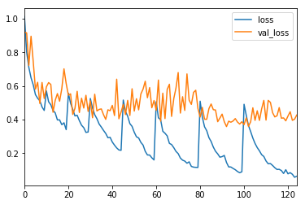

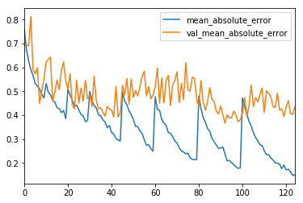

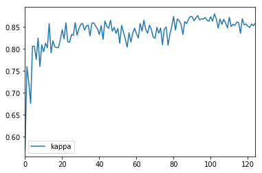

```python
results[['loss', 'val_loss']].plot()
results[['mean_absolute_error', 'val_mean_absolute_error']].plot()
results[['kappa']].plot()
results.to_csv('model_results.csv',index=False)
```

# Kappa Optimizer

```python
#https://www.kaggle.com/abhishek/optimizer-for-quadratic-weighted-kappa
class OptimizedRounder(object):
    def __init__(self):
        self.coef_ = 0

    def _kappa_loss(self, coef, X, y):
        X_p = np.copy(X)
        for i, pred in enumerate(X_p):
            if pred < coef[0]:
                X_p[i] = 0
            elif pred >= coef[0] and pred < coef[1]:
                X_p[i] = 1
            elif pred >= coef[1] and pred < coef[2]:
                X_p[i] = 2
            elif pred >= coef[2] and pred < coef[3]:
                X_p[i] = 3
            else:
                X_p[i] = 4

        ll = cohen_kappa_score(y, X_p, weights='quadratic')
        return -ll

    def fit(self, X, y):
        loss_partial = partial(self._kappa_loss, X=X, y=y)
        initial_coef = [0.5, 1.5, 2.5, 3.5]
        self.coef_ = sp.optimize.minimize(loss_partial, initial_coef, method='nelder-mead')
        print(-loss_partial(self.coef_['x']))

    def predict(self, X, coef):
        X_p = np.copy(X)
        for i, pred in enumerate(X_p):
            if pred < coef[0]:
                X_p[i] = 0
            elif pred >= coef[0] and pred < coef[1]:
                X_p[i] = 1
            elif pred >= coef[1] and pred < coef[2]:
                X_p[i] = 2
            elif pred >= coef[2] and pred < coef[3]:
                X_p[i] = 3
            else:
                X_p[i] = 4
        return X_p

    def coefficients(self):
        return self.coef_['x']
```

# Results

```python
model.load_weights('model.h5')
y_val_pred = model.predict(x_val)

optR = OptimizedRounder()
optR.fit(y_val_pred, y_val)
coefficients = optR.coefficients()
print(f'Coefficients: {coefficients}')
y_val_pred = optR.predict(y_val_pred, coefficients)

score = cohen_kappa_score(y_val_pred, y_val, weights='quadratic')

print('Optimized Validation QWK score: {}'.format(score))
print('Not Optimized Validation QWK score: {}'.format(max(results.kappa)))
```

```
0.8849103444249242
Coefficients: [0.60513711 1.36421993 2.52844061 3.07940899]
Optimized Validation QWK score: 0.8849103444249242
Not Optimized Validation QWK score: 0.8800029790943319
```

**Thanks for reading it all! Please let me know if you have any ideas to improve this process. Hope you liked it.**